# Taller 5: Correlaciones en R

Métodos Cuantitativos II

M. Constanza Ayala  
maria.ayala@uv.cl  
[Agenda una reunión aquí](https://outlook.office.com/bookwithme/user/6c3f9a95bb9d4c71abbc4d73b48d50d6@uv.cl/meetingtype/HPNElmMJ_UCckWs5QZTpdw2?anonymous&ismsaljsauthenabled&ep=mLinkFromTile)

Escuela de Sociología - Universidad de Valparaíso

15 de abril, 2026

## Pasemos lista mientras descargan los materiales y dejamos todo listo ✨

📂 **Paso 1:** Abrimos nuestro proyecto con doble clic en el archivo `.Rproj`

- Si no tienen proyecto, creamos uno: - `File > New Project > New Directory > New Project` - Creamos carpetas: `data`, `scripts`, `figures`, `output`

💾 **Paso 2:** Movemos el archivo **Script Taller 5 Métodos Cuantitativos II.R** a la carpeta `scripts`

📎 **Paso 3:** Verificamos que la base **base_93.Rds** esté en la carpeta `data`

> **Todos los materiales los pueden descargar en este link: [Materiales clases](https://github.com/mconstanzaa/met-cuanti-ii-uv-2026)**

## Actividades prácticas

A lo largo de la clase realizaremos **dos actividades prácticas** para ejercitar cada función vista.

No tienen nota, pero recomiendo resolverlas en un script aparte para que quede como material de estudio.

- Crea un script nuevo (no uses el script de actividades de la clase) e incluye un título, tu nombre, correo y fecha. Por ejemplo:

```r
# Actividades Taller 5 Métodos Cuantitativos II --------------------------------------------
# M. Constanza Ayala (maria.ayala@uv.cl)
# 15-04-2026
```

## Objetivos de la clase

- **Preparar** variables para el análisis: recodificación de valores perdidos
- **Calcular e interpretar** correlaciones de Pearson con `cor()` y `cor.test()`
- **Construir y visualizar** matrices de correlación con `tab_corr()` y `ggplot2`

## ¿Qué vimos la semana pasada en R?

✅ Usamos `mutate()` para crear nuevas variables

✅ Recodificamos valores perdidos con `case_when()`

✅ Recodificamos categorías con `case_when()`

💡 Hoy avanzamos hacia el **análisis bivariado**: correlación de Pearson.

## Preparación

Dejemos nuestro script preparado para los ejemplos y ejercicios de hoy.

```r
# Paquetes ----------------------------------------------------------------
library(tidyverse)
library(haven)
library(sjPlot)
library(labelled)

# Base de datos -----------------------------------------------------------
data <- readRDS("data/base_93.Rds")

# Etiquetar variables -----------------------------------------------------
data <- data %>%
  set_variable_labels(
    bienestar_2   = "Satisfacción con la vida",
    iden_pol_2    = "Autoidentificación ideológica",
    pobreza_62    = "Igualdad vs. esfuerzo individual",
    religion_63   = "Trabajo duro vs. suerte",
    democracia_38 = "Libertades vs. control delincuencia"
  )
```

## Repaso: ¿qué mide la correlación de Pearson?

El coeficiente $r$ de Pearson mide la **fuerza y dirección de una relación lineal** entre dos variables cuantitativas.

**Dirección:**

- $r > 0$: relación positiva — a mayor valor en $X$, mayor valor en $Y$
- $r < 0$: relación negativa — a mayor valor en $X$, menor valor en $Y$
- $r = 0$: no hay relación lineal entre las variables

**Fuerza:**

- Cuanto más se acerca $|r|$ a 1, más estrecha es la relación lineal
- Cuanto más se acerca $|r|$ a 0, más débil o inexistente es la asociación

## Variables que usaremos

Trabajaremos con cinco variables cuantitativas de la **Encuesta CEP N° 93**:

| Variable | Pregunta (resumida) | Escala |
| --- | --- | --- |
| `bienestar_2` | Satisfacción con la vida | 1–10 |
| `iden_pol_2` | Autoidentificación ideológica (izq.–der.) | 1–10 |
| `pobreza_62` | Igualdad de ingresos vs. esfuerzo individual | 1–10 |
| `religion_63` | Trabajo duro vs. suerte/contactos | 1–10 |
| `democracia_38` | Libertades individuales vs. control delincuencia | 0–10 |

> En todas estas variables, los valores **-8** (No sabe) y **-9** (No contesta) corresponden a **datos perdidos** y deben recodificarse como `NA` antes de cualquier análisis.

## Paso 1: recodificar valores perdidos

Ya lo practicaron en el Taller 4. Aquí lo aplicamos a las cinco variables usando `across()`, que permite operar sobre múltiples variables en una sola instrucción:

```r
data <- data %>%
  mutate(across(
    c(bienestar_2, iden_pol_2, pobreza_62, religion_63, democracia_38),
    ~ case_when(
      . %in% c(-8, -9) ~ NA_real_,
      TRUE ~ .
    )
  ))
```

Verificamos con `summary()`:

```r
data %>%
  select(bienestar_2, iden_pol_2, pobreza_62, religion_63, democracia_38) %>%
  summary()
```

```
  bienestar_2       iden_pol_2       pobreza_62      religion_63
 Min.   : 1.000   Min.   : 1.000   Min.   : 1.000   Min.   : 1.000
 1st Qu.: 6.000   1st Qu.: 5.000   1st Qu.: 5.000   1st Qu.: 5.000
 Median : 8.000   Median : 5.000   Median : 7.000   Median : 7.000
 Mean   : 7.463   Mean   : 5.424   Mean   : 7.064   Mean   : 6.961
 3rd Qu.:10.000   3rd Qu.: 7.000   3rd Qu.:10.000   3rd Qu.:10.000
 Max.   :10.000   Max.   :10.000   Max.   :10.000   Max.   :10.000
 NA's   :3        NA's   :416      NA's   :33       NA's   :22
 democracia_38
 Min.   : 0.000
 1st Qu.: 5.000
 Median : 6.000
 Mean   : 6.556
 3rd Qu.:10.000
 Max.   :10.000
 NA's   :68
```

## Paso 2: visualización

Antes de calcular $r$, usaremos un **gráfico de dispersión** con `ggplot2`:

```r
ggplot(data, aes(x = iden_pol_2, y = pobreza_62)) +  # variables en los ejes
  geom_jitter(alpha = 0.2,                            # puntos semitransparentes
              width = 0.2, height = 0.2) +            # separa puntos superpuestos en escalas discretas
  geom_smooth(method = "lm",                          # línea de tendencia lineal
              color = "steelblue") +                  # color de la línea
  labs(
    title = "Gráfico de dispersión: autoidentificación ideológica y preferencia por el esfuerzo individual",
    x = "Autoidentificación ideológica (1 = izquierda, 10 = derecha)",
    y = "Ingresos iguales vs. esfuerzo individual (1–10)",
    caption = "Fuente: Encuesta CEP N° 93"
  ) +
  theme_minimal()                                     # tema sin fondo gris
```

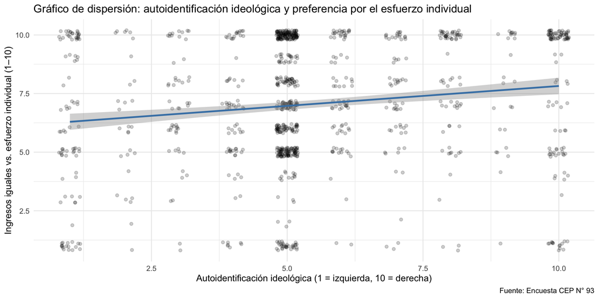

## ¿Qué observamos en el gráfico?

- Cada punto representa una persona encuestada.
- Los puntos tienen un desplazamiento aleatorio leve (`geom_jitter`) para evitar que se superpongan - ambas variables son escalas discretas de 10 puntos.
- La línea de tendencia tiene una pendiente **positiva**: quienes se identifican más a la derecha tienden a preferir en mayor medida premiar el esfuerzo individual por sobre la igualdad de ingresos.
- La alta dispersión de los puntos alrededor de la línea sugiere que la relación es **débil**.
- Se observa una concentración importante de casos en el valor 5 de la escala.

💡 El diagrama de dispersión no nos da un número, pero nos permite anticipar si la correlación será positiva, negativa, o si hay valores atípicos que podrían afectar el coeficiente.

## `cor()`: correlación puntual

La función `cor()` calcula el coeficiente $r$ de Pearson. Es importante especificar `use = "complete.obs"` para excluir los casos con `NA`:

```r
# Sin especificar el tratamiento de NA → el resultado es NA
cor(data$iden_pol_2, data$pobreza_62)
```

```
[1] NA
```

```r
# Especificando que se usen solo casos completos
cor(data$iden_pol_2, data$pobreza_62, use = "complete.obs")
```

```
[1] 0.147554
```

> Si olvidamos `use = "complete.obs"` y hay `NA` en los datos, `cor()` devuelve `NA`. Siempre hay que especificarlo.

## `cor.test()`: correlación con inferencia

`cor.test()` agrega **significancia estadística** al coeficiente:

```r
options(scipen = 999) # evita notación científica

cor.test(data$iden_pol_2, data$pobreza_62)
```

```
    Pearson's product-moment correlation

data:  data$iden_pol_2 and data$pobreza_62
t = 4.8618, df = 1062, p-value = 0.000001339
alternative hypothesis: true correlation is not equal to 0
95 percent confidence interval:
 0.08823754 0.20582767
sample estimates:
     cor
0.147554
```

## Interpretación

- **`t`**: estadístico de prueba para la hipótesis $H_0: \rho = 0$
- **`df`**: grados de libertad ($n - 2$)
- **`p-value`**: probabilidad de obtener un estadístico $t$ igual o más extremo que el observado, si no existiera asociación en la población ($H_0: \rho = 0$)
- **`cor`**: el coeficiente $r$ estimado
- **`95 percent confidence interval`**: rango plausible para el verdadero valor de $\rho$

Un $r$ = 0.15 indica que **quienes se identifican más a la derecha tienden a preferir en mayor medida premiar el esfuerzo individual por sobre la igualdad de ingresos**, aunque la relación es **débil**. El p-valor (*p < .001*) indica que esta relación es estadísticamente significativa, es decir, tenemos evidencia para afirmar que existe una asociación en la población.

## Actividad práctica 1

En el script, en una sección llamada `Correlación 1`:

1. Calcula con `cor()` la correlación entre `bienestar_2` (satisfacción con la vida) y `religion_63` (trabajo duro vs. suerte). Recuerda usar `use = "complete.obs"`.
2. Luego usa `cor.test()` para obtener el coeficiente con inferencia estadística.
3. Incluye en comentarios (`#`) una interpretación breve: ¿cuál es la dirección de la relación? ¿Es estadísticamente significativa? ¿Qué magnitud tiene según la relación?

## `tab_corr()`: matriz de correlaciones

Cuando queremos analizar las relaciones entre **más de dos variables simultáneamente**, usamos una matriz de correlaciones. El paquete `sjPlot` ofrece la función `tab_corr()`:

```r
# Seleccionamos las cinco variables de trabajo
vars_corr <- data %>%
  select(bienestar_2, iden_pol_2, pobreza_62, religion_63, democracia_38)
tab_corr(vars_corr, na.deletion = "pairwise")
```

|  | Satisfacción con la vida | Autoidentificación ideológica | Igualdad vs. esfuerzo individual | Trabajo duro vs. suerte | Libertades vs. control delincuencia |
| --- | --- | --- | --- | --- | --- |
| Satisfacción con la vida |  | 0.022 | 0.102*** | 0.088*** | 0.028 |
| Autoidentificación ideológica | 0.022 |  | 0.148*** | 0.114*** | 0.253*** |
| Igualdad vs. esfuerzo individual | 0.102*** | 0.148*** |  | 0.228*** | 0.130*** |
| Trabajo duro vs. suerte | 0.088*** | 0.114*** | 0.228*** |  | 0.137*** |
| Libertades vs. control delincuencia | 0.028 | 0.253*** | 0.130*** | 0.137*** |  |
| Computed correlation used pearson-method with pairwise-deletion. |  |  |  |  |  |

Para mayor legibilidad, podemos mostrar solo el **triángulo inferior** de la matriz (el triángulo superior es simétrico y repite la información):

```r
tab_corr(vars_corr, , na.deletion = "pairwise", triangle = "lower")
```

|  | Satisfacción con la vida | Autoidentificación ideológica | Igualdad vs. esfuerzo individual | Trabajo duro vs. suerte | Libertades vs. control delincuencia |
| --- | --- | --- | --- | --- | --- |
| Satisfacción con la vida |  |  |  |  |  |
| Autoidentificación ideológica | 0.022 |  |  |  |  |
| Igualdad vs. esfuerzo individual | 0.102*** | 0.148*** |  |  |  |
| Trabajo duro vs. suerte | 0.088*** | 0.114*** | 0.228*** |  |  |
| Libertades vs. control delincuencia | 0.028 | 0.253*** | 0.130*** | 0.137*** |  |
| Computed correlation used pearson-method with pairwise-deletion. |  |  |  |  |  |

> Los asteriscos indican niveles de significancia: `*` p < .05, `**` p < .01, `***` p < .001.

## Visualización de la matriz: `ggplot2`

También podemos visualizar la matriz como un **mapa de calor** (*heatmap*). Esto facilita la lectura cuando hay muchas variables:

```r
# Calculamos la matriz de correlaciones (solo casos completos)
mat_corr <- cor(vars_corr, use = "complete.obs")

# Convertimos la matriz a formato largo: una fila por par de variables
mat_long <- as.data.frame(as.table(mat_corr))

# Renombramos las columnas para facilitar el trabajo con ggplot2
names(mat_long) <- c("Variable1", "Variable2", "r")

ggplot(mat_long, aes(x = Variable1, y = Variable2, fill = r)) +  # ejes y color según r
  geom_tile(color = "white") +                    # celdas con borde blanco
  geom_text(aes(label = round(r, 2)), size = 3.5) +              # valor de r en cada celda
  scale_fill_gradient2(
    low = "#d73027",                              # rojo: correlación negativa
    mid = "white",                                # blanco: correlación cercana a 0
    high = "#4575b4",                             # azul: correlación positiva
    midpoint = 0, limits = c(-1, 1), name = "r"  # escala centrada en 0
  ) +
  labs(
    title = "Matriz de correlaciones",
    caption = "Fuente: Encuesta CEP N° 93"
  ) +
  theme_minimal() +
  theme(axis.text.x = element_text(angle = 30, hjust = 1))  # etiquetas eje x inclinadas
```

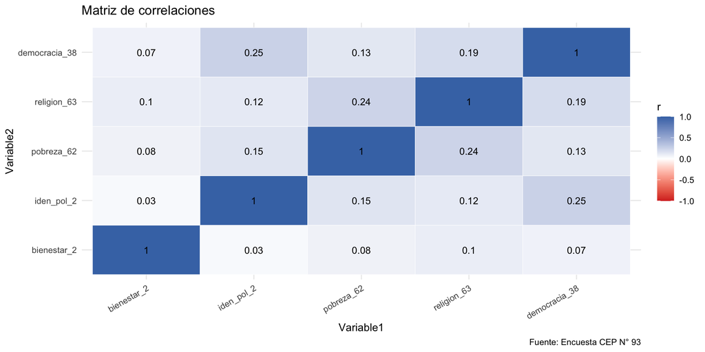

## Actividad práctica 2

En el script, en una sección llamada `Matriz de correlaciones`:

1. Crea un objeto llamado `vars_ejercicio` seleccionando con `select()` las variables `bienestar_23_a`, `bienestar_23_b`, `bienestar_23_c` y `bienestar_23_d` (preocupación por problemas en el barrio, escala 0–10). Recuerda aplicar primero la recodificación de `-7`, `-8` y `-9` como `NA`.
2. Genera una matriz de correlaciones con `tab_corr()` mostrando solo el triángulo inferior.
3. Genera el mapa de calor con `ggplot2`.
4. Incluye en comentarios (`#`) una interpretación breve: ¿qué par de ítems está más correlacionado? ¿Qué implicancia tiene eso en términos de lo que miden estos ítems?

## ❓ Preguntas y aclaraciones

💬 **¿Dudas sobre lo visto hoy?**

- Tómense un momento para reflexionar y compartir preguntas sobre el contenido.
- Espacio para responder inquietudes y aclarar conceptos clave.

## Resumen clase de hoy

✅ Recodificamos valores perdidos en variables con `mutate()` y `across()`

✅ Visualizamos relaciones bivariadas con diagramas de dispersión en `ggplot2`

✅ Calculamos correlaciones de Pearson con `cor()` y `cor.test()`

✅ Construimos matrices de correlación con `tab_corr()` y mapas de calor con `ggplot2`

## 📆 Próxima sesión

- Regresión lineal simple en R

## 📚 Sugerencias lecturas para reforzar R

- Wickham & Grolemund. R for Data Science (acceso en línea biblioteca, en español: https://es.r4ds.hadley.nz/)
- [AnalizaR Datos Políticos](https://arcruz0.github.io/libroadp/index.html)
- [YaRrr! The Pirate’s Guide to R](https://bookdown.org/ndphillips/YaRrr/)